# Evaluating Causal Effects of Mixed Exposures using Data Adaptive Decision Trees and CV-TMLE

[David McCoy]

2022-09-01

## Introduction

Data adaptive target parameters constitute a flexible framework for estimating the effects of a data adaptively determined target parameter. There is a literature on the dangers of deriving parameters data-adaptively and the common approach for deriving consistent inference for a data-adaptively defined parameter is to use sample-splitting. In sample-splitting the researcher splits the full data into a training set used to define the parameter, and an estimation sample in which estimates are derived given the parameter identified in training. Of course this approach can be costly when new samples are collected for the estimation data or loses power when the full data is simply split. Our proposed approach for decision trees applied to mixtures, aims to preserve the data-adaptive part of the sample splitting algorithm but we define an average of the data-adaptive parameter estimates across estimation samples based on arbitrary splits in V-fold cross-validation. In this way, one can still use the power of the entire dataset. The `CVtreeMLE` package implements decision tree algorithms for computing thresholds in exposures that best explain an outcome while flexibly adjusting for covariates. The nodes in decision trees are represented as a binary exposures for which targeted minimum loss-based estimates (TMLE) are derived for the counterfactual mean outcome difference if all individual were exposed to the rule compared to if no one was exposed to the mixture.

Two types of results are given for decision trees identified in the mixture and marginal space of the exposure. V-fold specific results give the ATE and variance estimates for a fold specific set of rules. The pooled ATE takes the average across folds to gain power (reduce variance). We give both so that researchers can look to see how consistent rules are given sample splitting which adds information to the pooled result.

For a technical presentation, the interested reader is invited to consult (**mccoy2022CVtreeMLE?**) or the earlier work of van der Laan and Rose (2011), van der Laan and Rose (2018), and van der Laan et al. (2022). For more background on data-adaptive target parameters see Hubbard, Kherad-Pajouh, and Van Der Laan (2016) and chapter 9 in van der Laan and Rose (2018).

To start, let’s load the packages we’ll need and set a seed for simulation. We will use a real-world data example with known ground-truth to show the functionality of `CVtreeMLE`.

```r
library(data.table)
library(CVtreeMLE)
library(sl3)
library(pre)
library(partykit)
library(kableExtra)
library(dplyr)
library(ggplot2)
library(purrr)

seed <- 5454432
set.seed(seed)
```

## National Institute of Environmental Health Data

We will use simulated data from the 2015 NIEHS Mixtures Workshop which was developed to determine if new mixture methods detect ground-truth interactions built into the simulated data. In this way we can simultaneously show `CVtreeMLE` output, interpretation and validity.

```r
niehs_data <- NIEHS_data_1

head(niehs_data) %>%
  kableExtra::kbl(caption = "NIEHS Data") %>%
  kableExtra::kable_classic(full_width = FALSE, html_font = "Cambria")
```

NIEHS Data

| obs | Y | X1 | X2 | X3 | X4 | X5 | X6 | X7 | Z |
| --- | --- | --- | --- | --- | --- | --- | --- | --- | --- |
| 1 | 7.534686 | 0.4157066 | 0.5308077 | 0.2223965 | 1.1592634 | 2.4577556 | 0.9438601 | 1.8714406 | 0 |
| 2 | 19.611934 | 0.5293572 | 0.9339570 | 1.1210595 | 1.3350074 | 0.3096883 | 0.5190970 | 0.2418065 | 0 |
| 3 | 12.664050 | 0.4849759 | 0.7210988 | 0.4629027 | 1.0334138 | 0.9492810 | 0.3664090 | 0.3502445 | 0 |
| 4 | 15.600288 | 0.8275456 | 1.0457137 | 0.9699040 | 0.9045099 | 0.9107914 | 0.4299847 | 1.0007901 | 0 |
| 5 | 18.606498 | 0.5190363 | 0.7802400 | 0.6142188 | 0.3729743 | 0.5038126 | 0.3575472 | 0.5906156 | 0 |
| 6 | 18.525890 | 0.4009491 | 0.8639886 | 0.5501847 | 0.9011016 | 1.2907615 | 0.7990418 | 1.5097039 | 0 |

For detailed information on this simulated data please see:

https://github.com/niehs-prime/2015-NIEHS-MIxtures-Workshop

Briefly, this synthetic data can be considered the results of a prospective cohort epidemiologic study. The outcome cannot cause the exposures (as might occur in a cross-sectional study). Correlations between exposure variables can be thought of as caused by common sources or modes of exposure. The nuisance variable Z can be assumed to be a potential confounder and not a collider. There are 7 exposures which have a complicated dependency structure. $X_3$ and $X_6$ do not have an impact on the outcome.

One issue is that many machine learning algorithms will fail given only 1 variable passed as a feature so let’s add some other covariates.

```r
niehs_data$Z2 <- rbinom(nrow(niehs_data),
                                        size = 1,
                                        prob = 0.3)

niehs_data$Z3 <- rbinom(nrow(niehs_data),
                                        size = 1,
                                        prob = 0.1)
```

## Run `CVtreeMLE`

```r
ptm <- proc.time()

niehs_results <- CVtreeMLE(data = as.data.frame(niehs_data),
                         w = c("Z", "Z2", "Z3"),
                         a = c(paste("X", seq(7), sep = "")),
                         y = "Y",
                         n_folds = 5,
                         seed = seed,
                         parallel_cv = TRUE,
                         family = "gaussian",
                         num_cores = 6,
                         max_iter = 1)
proc.time() - ptm
```

```
#>    user  system elapsed
#> 116.118  11.606 901.719
```

## Mixture Results

We can look at the pooled TMLE results for this model, let’s focus on the results that are found consistently across all the folds. By consistent we mean rules that have the same sets of variables with the same direction of effect across all the folds. Weaker interactions may only be found in some folds, here we will focus on the strongest:

```r
pooled_mixture_results <- niehs_results$`Pooled TMLE Mixture Results`

pooled_mixture_results %>%
  dplyr::filter(Proportion_Folds == 1.0)  %>%
  dplyr::arrange(desc(`Mixture ATE`)) %>%
  kableExtra::kbl(caption = "Pooled TMLE Mixture Results") %>%
  kableExtra::kable_classic(full_width = FALSE, html_font = "Cambria")
```

Pooled TMLE Mixture Results

| Mixture ATE | Standard Error | Lower CI | Upper CI | P-value | P-value Adj | Vars | RMSE | Union_Rule | Proportion_Folds |
| --- | --- | --- | --- | --- | --- | --- | --- | --- | --- |
| 7.552 | 0.473 | 6.625 | 8.480 | 0 | 0 | X5X7 | 5.493 | X5 > 0.05 & X5 < 1.324 & X7 > 0.242 & X7 < 4.886 | 1 |
| 7.166 | 0.557 | 6.076 | 8.257 | 0 | 0 | X2X7 | 5.490 | X2 > 0.802 & X2 < 2.467 & X7 > 1.14 & X7 < 4.886 | 1 |
| 6.428 | 0.588 | 5.275 | 7.580 | 0 | 0 | X2X5 | 5.542 | X2 > 0.727 & X2 < 2.467 & X5 > 0.067 & X5 < 2.856 | 1 |

Above, the pooled mixture ATE for each rule is given. Let’s focus on the first row that has $X_5*X_7$. The Mixture ATE shows the ATE, or the expected mean outcome difference if all individuals were exposed to the mixture rule compared to if no individuals were exposed to the mixture rule. So in the first row the ATE is 7.5 which means the endocrine disruption outcome is 7.5 higher if all individuals were exposed to the thresholds shown in union rule compared to if no individuals were exposed to this rule.

This ATE is calculated by pooling the nuisance parameter values across the validation folds and doing a TMLE update on the initial counterfactuals across the full data. Standard error, CIs and P-values are derived from the efficient influence function. Because rules may deviate from fold to fold we create a union rule. To see this more clearly let’s look at the fold specific results for this so-called interaction:

```r
vfold_mixture_results <- niehs_results$`V-Specific Mix Results`

vfold_mixture_results$X5X7 %>%
  kableExtra::kbl(caption = "X5 and X7 Interaction") %>%
  kableExtra::kable_classic(full_width = FALSE, html_font = "Cambria")
```

X5 and X7 Interaction

| ate | se | lower_ci | upper_ci | p_val | p_val_adj | rmse | mix_rule | fold | variables |
| --- | --- | --- | --- | --- | --- | --- | --- | --- | --- |
| 6.845 | 1.105 | 4.6800 | 9.0100 | 0.000000 | 0.000000 | 5.719 | X7 > 0.669 & X5 <= 1.332 | 1 | X5X7 |
| 7.799 | 1.049 | 5.7420 | 9.8550 | 0.000000 | 0.000000 | 5.892 | X7 > 0.958 & X5 <= 0.374 | 2 | X5X7 |
| 5.633 | 1.089 | 3.4980 | 7.7680 | 0.000000 | 0.000001 | 6.055 | X7 > 0.503 & X5 <= 0.611 | 3 | X5X7 |
| 4.561 | 1.481 | 1.6570 | 7.4640 | 0.002078 | 0.010389 | 6.322 | X7 > 0.24 & X5 <= 0.313 | 4 | X5X7 |
| 6.998 | 1.275 | 4.5000 | 9.4970 | 0.000000 | 0.000000 | 5.681 | X5 <= 0.709 & X7 > 0.361 | 5 | X5X7 |
| 6.542 | 2.707 | 1.2373 | 11.8474 | 0.015650 | 0.015650 | 5.909 | X5 > 0.05 & X5 < 1.324 & X7 > 0.242 & X7 < 4.886 | Pooled | X5X7 |

Above we see the fold specific results for $X_5 * X_7$. Let’s focus on $X_5$ in the rules listed under *mix_rule*. Here we see that in fold 1 the threshold for $X_5$ is 1.332, in fold 2 it’s 0.374 etc. Of these thresholds we select the highest because this value covers observations indicated by lower thresholds. This is because, in the case of $X_5$ the direction is less than or equal to. What happens under the hood is, for rules that have the same variables, we create a new rule that is rule 1 OR rule 2 OR … and then look at the min and max of each variable within this rule - this creates the union rule which encompasses all observations indicated by the rules across the folds.

So in our union rule the threshold for $X_5$ is 1.324 because this threshold covers all other observations indicated by slightly lower rules in the other folds. The same is true for $X_7$ but we select the lower threshold because the direction is $>=$. This is why in the first table the union rule is X5 < 1.324 & X7 > 0.242. This rule covers all observations indicated by the fold specific rules used to generate the ATE.

Overall, the ATE for this rule is 7.5 for the pooled TMLE estimate. We see this is higher than if we were to simply take a weighted average which is shown in the pooled row above.

What happens is that the nuisance parameters used to generate the v-fold specific results are instead pooled and a TMLE update is done across all the validation data. This is why the results for the pooled TMLE update are different compared to the pooled result shown in the v-fold specific table, this is the weighted average across the folds, similar to a meta-analysis.

## Plotting Fold Specific Mixture Trees

If the user wants to extract plots of the rules found in the `pre` model for each fold we can plot results from the model.

Here we will plot some rules found in the first fold - the indices we pass here are for the fold that we want to extract models for. Using the `pre` plot method, we can plot the rules in the ensemble as simple decision trees. Here, we plot the nine most important basis functions through specification of the nterms argument.

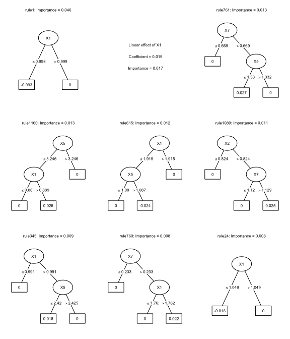

```r
fold_1_model <- niehs_results$`Mixture Models`[[1]]
plot(fold_1_model, nterms = 9, cex = .5)
```

The purpose of this plotting procedure is to allow the user some method for investigating the best fitting model found in the mixture interative backfitting procedure. Also, these plots can be used if the user wants to include them as figures with the v-fold specific ATE for the specific rule.

## Comparing Mixture Rules to Ground-Truth

In terms of toxicology, there are the following kinds of interaction (relative to concentration addition) in this data:

- X1 and X2 TEF (toxic equivalent factor), a special case of concentration addition (both increase Y)
- X1 and X4 competitive antagonism (similarly for X2 and X4) - found
- X1 and X5 competitive antagonism (similarly for X2 and X4) - found
- X1 and X7 supra-additive (“synergy”) (similarly for X2 and X7) - found
- X4 and X5 TEF, a type of concentration addition (both decrease y)
- X4 and X7 antagonism (unusual kind) (similarly for X5 and X7) - found

As we can see, $X_5 * X_7$ is listed as having antagonism. This is picked up in `CVtreeMLE` because the thresholds that define the ATE are for regions where $X_7$ is high and $X_5$ is low. Thus the impact is greater in this region because $X_5$ antagonizes the effect of $X_7$. As such, we would expect a threshold determined where $X_5$ is low and $X_7$ is high.

Let’s look at the consistent rules found by `CVtreeMLE`, we defined consistent as found in 80% of the folds. Of course, more consistent results will be found if using 10-fold CV compared to 5 but we can use this as an example:

```r
pooled_mixture_results %>%
  dplyr::filter(Proportion_Folds >= 0.8)  %>%
  dplyr::arrange(desc(`Mixture ATE`)) %>%
  kableExtra::kbl(caption = "Consistent Pooled TMLE Mixture Results") %>%
  kableExtra::kable_classic(full_width = FALSE, html_font = "Cambria")
```

Consistent Pooled TMLE Mixture Results

| Mixture ATE | Standard Error | Lower CI | Upper CI | P-value | P-value Adj | Vars | RMSE | Union_Rule | Proportion_Folds |
| --- | --- | --- | --- | --- | --- | --- | --- | --- | --- |
| 8.260 | 0.486 | 7.309 | 9.212 | 0 | 0 | X1X5 | 5.862 | X1 > 0.267 & X1 < 4.687 & X5 > 0.05 & X5 < 3.488 | 0.8 |
| 7.654 | 0.750 | 6.184 | 9.125 | 0 | 0 | X2X5X7 | 5.122 | X2 > 0.821 & X2 < 2.467 & X5 > 0.067 & X5 < 3.098 & X7 > 0.317 & X7 < 4.886 | 0.8 |
| 7.552 | 0.473 | 6.625 | 8.480 | 0 | 0 | X5X7 | 5.493 | X5 > 0.05 & X5 < 1.324 & X7 > 0.242 & X7 < 4.886 | 1.0 |
| 7.548 | 0.574 | 6.423 | 8.673 | 0 | 0 | X1X7 | 5.941 | X1 > 1.01 & X1 < 4.687 & X7 > 0.26 & X7 < 4.886 | 0.8 |
| 7.166 | 0.557 | 6.076 | 8.257 | 0 | 0 | X2X7 | 5.490 | X2 > 0.802 & X2 < 2.467 & X7 > 1.14 & X7 < 4.886 | 1.0 |
| 6.929 | 0.557 | 5.837 | 8.021 | 0 | 0 | X3X7 | 5.539 | X3 > 0.88 & X3 < 4.565 & X7 > 1.033 & X7 < 4.886 | 0.8 |
| 6.428 | 0.588 | 5.275 | 7.580 | 0 | 0 | X2X5 | 5.542 | X2 > 0.727 & X2 < 2.467 & X5 > 0.067 & X5 < 2.856 | 1.0 |

So here we see that, when using 5-fold CV, we detect 4 of thre 6 built in interactions.

## Plotting Mixture Results

We can plot our v-fold mixture results findings using the `plot_mixture_results` function. This will plot a dot and whisker plot showing the ATE and CIs for each rule in the fold with the rule overlaid on the plot.

We first run the `plot_mixture_results` function to get a list of plots for each mixture rule found.

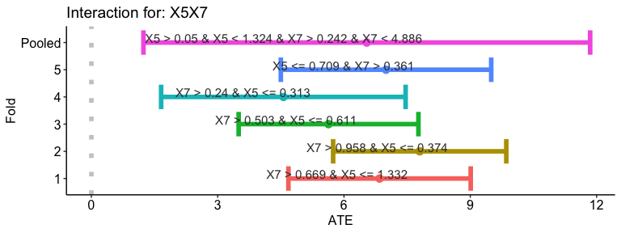

```r
mixture_plots <- plot_mixture_results(
  v_intxn_results = niehs_results$`V-Specific Mix Results`,
  hjust = 0.8)
mixture_plots$X5X7
```

The goal of this plot is to give users a visual inspection of how consistent results are for a specific rule.

Above we see the ATE estimates for thresholds determined in $X_7*X_5$. Overlaid on these dot-whisker plots is the rule determined in each of the folds. On the Y-axis, Pooled is the overall pooled estimate. This is a weighted average of the ATEs across the folds with the harmonic mean of the variances. This is different compared to the pooled TMLE result and we give this estimate for plotting purposes and to show the benefit of using the pooled TMLE estimate which has the lowest variance.

## Reporting Mixture Results

Here we give an example of how to report results from `CVtreeMLE` using the $X_7*X_5$ results found.

## Marginal Results

`CVtreeMLE` also estimates marginal thresholds for each exposure if the exposure has explanatory power on the outcome. Here, ensemble decision trees are fit to each exposure individually while controlling for other mixture components and covariates. ATEs are given by comparing each region found to the lowest region determined.

For the marginal results, it is easier to begin looking at the v-fold specific results. Let’s first look at the fold specific decision trees found for the variable X1.

## Plotting Marginal Decision Trees

First we can extract all the fold specific models for the variable X1.

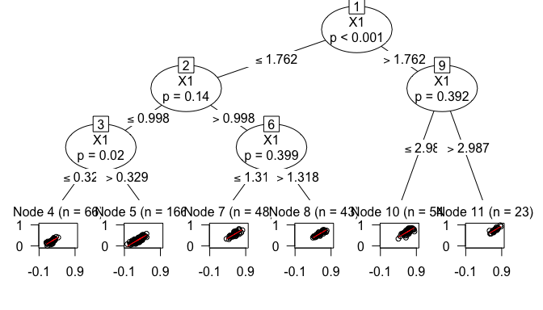

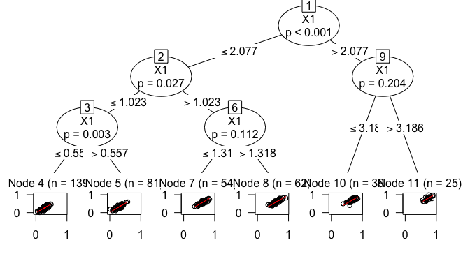

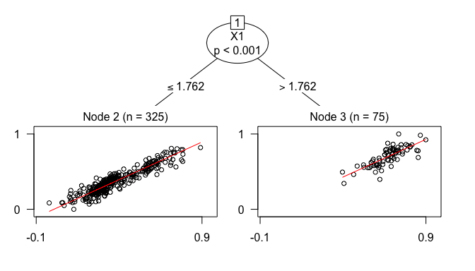

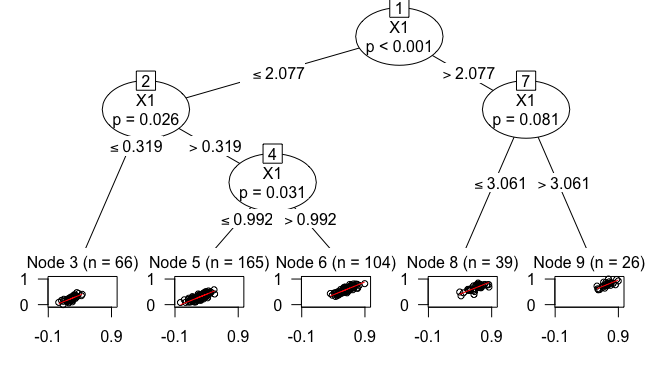

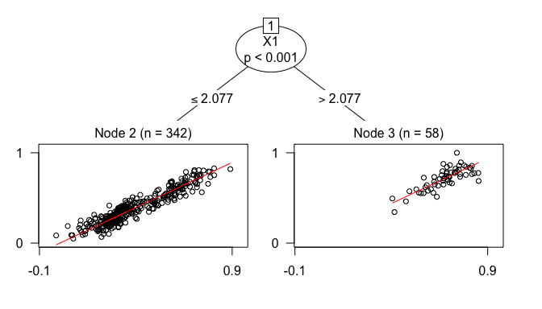

```r
x1_models <- map(niehs_results$`Marginal Models`, "X1")
sapply(x1_models, plot)
```

Because we have 5 folds, above we show 5 decision trees found for the variable X1 that were determined using cross-validation to select the best fitting decision tree while flexibly adjusting for covariates using Super Learner. These are found during the marginal backfitting procedure where we fit a Super Learner of decision trees on the variable X1 and a Super Learner of other algorithms on the covariates and other exposures.

```r
fold_marginal_results <- niehs_results$`V-Specific Marg Results`

fold_marginal_results %>%
  filter(Levels == "X1_2-X1_1") %>%
  kableExtra::kbl(
    caption = "V-fold specific results for X1 regions 1 and 2") %>%
  kableExtra::kable_classic(full_width = FALSE, html_font = "Cambria")
```

V-fold specific results for X1 regions 1 and 2

|  | Marginal ATE | Standard Error | Lower CI | Upper CI | P-value | P-value Adj | RMSE | Levels | Reference_Rule | Comparison_Rule | fold | var |
| --- | --- | --- | --- | --- | --- | --- | --- | --- | --- | --- | --- | --- |
| X1_2-X1_1.1 | 1.486 | 0.736 | 0.044 | 2.929 | 0.043465 | 1 | 6.887 | X1_2-X1_1 | X1 <= 1.762 & X1 <= 0.998 & X1 <= 0.329 | X1 <= 1.762 & X1 <= 0.998 & X1 > 0.329 | 1 | X1 |
| X1_2-X1_1.2 | 1.682 | 1.342 | -0.948 | 4.311 | 0.209964 | 1 | 6.552 | X1_2-X1_1 | X1 <= 2.077 & X1 <= 1.023 & X1 <= 0.557 | X1 <= 2.077 & X1 <= 1.023 & X1 > 0.557 | 2 | X1 |
| X1_2-X1_1.3 | 5.416 | 1.069 | 3.321 | 7.512 | 0 | 0 | 7.169 | X1_2-X1_1 | X1 <= 1.762 | X1 > 1.762 | 3 | X1 |
| X1_2-X1_1.4 | 1.521 | 0.661 | 0.226 | 2.815 | 0.021314 | 1 | 6.198 | X1_2-X1_1 | X1 <= 2.077 & X1 <= 0.319 | X1 <= 2.077 & X1 > 0.319 & X1 <= 0.992 | 4 | X1 |
| X1_2-X1_1.5 | 6.57 | 1.105 | 4.404 | 8.735 | 0 | 0 | 5.834 | X1_2-X1_1 | X1 <= 2.077 | X1 > 2.077 | 5 | X1 |
| X1_2-X1_1.6 | 2.706 | 2.268 | -1.738 | 7.152 | 0.23272 | 0.23272 | 6.514 | X1_2-X1_1 | X1 > 0.048 & X1 < 2.077 | X1 > 0.326 & X1 < 4.687 | Pooled | X1 |

Above we get the ATE, variance and CIs for each fold comparing the region directly above the reference region to the reference region. As can be seen the reference rule corresponds to the far left leaf of each tree in our plots. The rule under comparison rule corresponds to the leaf of the tree one to the right of the reference region. Because this comparison exists for all our folds we get 5 ATEs. These results give us an idea of how consistent the thresholds are found across the folds.

## Reporting V-Fold Marginal Results

We can report the fold specific ATEs for regions found in each variable with valid inference. In the case of X1 we could chose 1 fold and simply report the resulting ATEs for each terminal node in that tree. This has valid inference because our target parameter is still estimated on the estimation data (not used in training) however our variance will be higher because of few samples in the estimation sample for the respective fold.

```r
fold_marginal_results <- niehs_results$`V-Specific Marg Results`

fold_marginal_results %>%
  filter(fold == "1") %>%
  filter(var == "X1") %>%
  kableExtra::kbl(
    caption = "V-fold specific results for X1 in Fold 1") %>%
  kableExtra::kable_classic(full_width = FALSE, html_font = "Cambria")
```

V-fold specific results for X1 in Fold 1

|  | Marginal ATE | Standard Error | Lower CI | Upper CI | P-value | P-value Adj | RMSE | Levels | Reference_Rule | Comparison_Rule | fold | var |
| --- | --- | --- | --- | --- | --- | --- | --- | --- | --- | --- | --- | --- |
| X1_2-X1_1.1 | 1.486 | 0.736 | 0.044 | 2.929 | 0.043465 | 1 | 6.887 | X1_2-X1_1 | X1 <= 1.762 & X1 <= 0.998 & X1 <= 0.329 | X1 <= 1.762 & X1 <= 0.998 & X1 > 0.329 | 1 | X1 |
| X1_3-X1_1.1 | 5.558 | 0.69 | 4.206 | 6.911 | 0 | 0 | 6.253 | X1_3-X1_1 | X1 <= 1.762 & X1 <= 0.998 & X1 <= 0.329 | X1 <= 1.762 & X1 > 0.998 & X1 <= 1.318 | 1 | X1 |
| X1_4-X1_1.1 | 5.608 | 0.714 | 4.208 | 7.008 | 0 | 0 | 6.935 | X1_4-X1_1 | X1 <= 1.762 & X1 <= 0.998 & X1 <= 0.329 | X1 <= 1.762 & X1 > 0.998 & X1 > 1.318 | 1 | X1 |
| X1_5-X1_1.1 | 8.838 | 0.641 | 7.581 | 10.095 | 0 | 0 | 6.155 | X1_5-X1_1 | X1 <= 1.762 & X1 <= 0.998 & X1 <= 0.329 | X1 > 1.762 & X1 <= 2.987 | 1 | X1 |
| X1_6-X1_1.1 | 11.281 | 1.036 | 9.251 | 13.311 | 0 | 0 | 6.767 | X1_6-X1_1 | X1 <= 1.762 & X1 <= 0.998 & X1 <= 0.329 | X1 > 1.762 & X1 > 2.987 | 1 | X1 |

Let’s grab our decision tree that corresponds to these results:

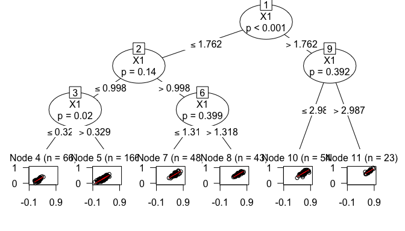

```r
plot(x1_models[[1]])
```

It should be noted that the higher regions above the reference region are not found across all the folds. Let’s look again at our output for X1.

```r
fold_marginal_results %>%
  filter(var == "X1") %>%
  kableExtra::kbl(
    caption = "V-fold specific results for X1") %>%
  kableExtra::kable_classic(full_width = FALSE, html_font = "Cambria")
```

V-fold specific results for X1

|  | Marginal ATE | Standard Error | Lower CI | Upper CI | P-value | P-value Adj | RMSE | Levels | Reference_Rule | Comparison_Rule | fold | var |
| --- | --- | --- | --- | --- | --- | --- | --- | --- | --- | --- | --- | --- |
| X1_2-X1_1.1 | 1.486 | 0.736 | 0.044 | 2.929 | 0.043465 | 1 | 6.887 | X1_2-X1_1 | X1 <= 1.762 & X1 <= 0.998 & X1 <= 0.329 | X1 <= 1.762 & X1 <= 0.998 & X1 > 0.329 | 1 | X1 |
| X1_2-X1_1.2 | 1.682 | 1.342 | -0.948 | 4.311 | 0.209964 | 1 | 6.552 | X1_2-X1_1 | X1 <= 2.077 & X1 <= 1.023 & X1 <= 0.557 | X1 <= 2.077 & X1 <= 1.023 & X1 > 0.557 | 2 | X1 |
| X1_2-X1_1.3 | 5.416 | 1.069 | 3.321 | 7.512 | 0 | 0 | 7.169 | X1_2-X1_1 | X1 <= 1.762 | X1 > 1.762 | 3 | X1 |
| X1_2-X1_1.4 | 1.521 | 0.661 | 0.226 | 2.815 | 0.021314 | 1 | 6.198 | X1_2-X1_1 | X1 <= 2.077 & X1 <= 0.319 | X1 <= 2.077 & X1 > 0.319 & X1 <= 0.992 | 4 | X1 |
| X1_2-X1_1.5 | 6.57 | 1.105 | 4.404 | 8.735 | 0 | 0 | 5.834 | X1_2-X1_1 | X1 <= 2.077 | X1 > 2.077 | 5 | X1 |
| X1_2-X1_1.6 | 2.706 | 2.268 | -1.738 | 7.152 | 0.23272 | 0.23272 | 6.514 | X1_2-X1_1 | X1 > 0.048 & X1 < 2.077 | X1 > 0.326 & X1 < 4.687 | Pooled | X1 |
| X1_3-X1_1.1 | 5.558 | 0.69 | 4.206 | 6.911 | 0 | 0 | 6.253 | X1_3-X1_1 | X1 <= 1.762 & X1 <= 0.998 & X1 <= 0.329 | X1 <= 1.762 & X1 > 0.998 & X1 <= 1.318 | 1 | X1 |
| X1_3-X1_1.2 | 5.363 | 0.612 | 4.164 | 6.562 | 0 | 0 | 6.213 | X1_3-X1_1 | X1 <= 2.077 & X1 <= 1.023 & X1 <= 0.557 | X1 <= 2.077 & X1 > 1.023 & X1 <= 1.318 | 2 | X1 |
| X1_3-X1_1.3 | 5.854 | 0.531 | 4.813 | 6.894 | 0 | 0 | 6.592 | X1_3-X1_1 | X1 <= 2.077 & X1 <= 0.319 | X1 <= 2.077 & X1 > 0.319 & X1 > 0.992 | 3 | X1 |
| X1_3-X1_1.4 | 5.622 | 1.064 | 3.536 | 7.707 | 0 | 0 | 6.385 | X1_3-X1_1 | X1 > 0.048 & X1 < 0.556 | X1 > 0.998 & X1 < 2.077 | Pooled | X1 |
| X1_4-X1_1.1 | 5.608 | 0.714 | 4.208 | 7.008 | 0 | 0 | 6.935 | X1_4-X1_1 | X1 <= 1.762 & X1 <= 0.998 & X1 <= 0.329 | X1 <= 1.762 & X1 > 0.998 & X1 > 1.318 | 1 | X1 |
| X1_4-X1_1.2 | 0 | 0.577 | -1.131 | 1.131 | 1 | 1 | 6.307 | X1_4-X1_1 | X1 <= 2.077 & X1 <= 1.023 & X1 <= 0.557 | X1 <= 2.077 & X1 > 1.023 & X1 > 1.318 | 2 | X1 |
| X1_4-X1_1.3 | 8.313 | 0.8 | 6.744 | 9.881 | 0 | 0 | 6.676 | X1_4-X1_1 | X1 <= 2.077 & X1 <= 0.319 | X1 > 2.077 & X1 <= 3.061 | 3 | X1 |
| X1_4-X1_1.4 | 3.675 | 1.218 | 1.288 | 6.062 | 0.00254 | 0.00254 | 6.584 | X1_4-X1_1 | X1 > 0.048 & X1 < 0.556 | X1 > 1.318 & X1 < 3.061 | Pooled | X1 |
| X1_5-X1_1.1 | 8.838 | 0.641 | 7.581 | 10.095 | 0 | 0 | 6.155 | X1_5-X1_1 | X1 <= 1.762 & X1 <= 0.998 & X1 <= 0.329 | X1 > 1.762 & X1 <= 2.987 | 1 | X1 |
| X1_5-X1_1.2 | 8.1 | 0.608 | 6.909 | 9.292 | 0 | 0 | 5.795 | X1_5-X1_1 | X1 <= 2.077 & X1 <= 1.023 & X1 <= 0.557 | X1 > 2.077 & X1 <= 3.186 | 2 | X1 |
| X1_5-X1_1.3 | 12.738 | 0.888 | 10.998 | 14.478 | 0 | 0 | 5.656 | X1_5-X1_1 | X1 <= 2.077 & X1 <= 0.319 | X1 > 2.077 & X1 > 3.061 | 3 | X1 |
| X1_5-X1_1.4 | 9.298 | 1.253 | 6.843 | 11.753 | 0 | 0 | 5.904 | X1_5-X1_1 | X1 > 0.048 & X1 < 0.556 | X1 > 1.764 & X1 < 4.687 | Pooled | X1 |
| X1_6-X1_1.1 | 11.281 | 1.036 | 9.251 | 13.311 | 0 | 0 | 6.767 | X1_6-X1_1 | X1 <= 1.762 & X1 <= 0.998 & X1 <= 0.329 | X1 > 1.762 & X1 > 2.987 | 1 | X1 |
| X1_6-X1_1.2 | 11.936 | 0.657 | 10.647 | 13.224 | 0 | 0 | 5.317 | X1_6-X1_1 | X1 <= 2.077 & X1 <= 1.023 & X1 <= 0.557 | X1 > 2.077 & X1 > 3.186 | 2 | X1 |
| X1_6-X1_1.3 | 11.748 | 1.227 | 9.344 | 14.152 | 0 | 0 | 5.733 | X1_6-X1_1 | X1 > 0.048 & X1 < 0.556 | X1 > 2.987 & X1 < 4.687 | Pooled | X1 |

As such, when reporting v-fold specific results, it is important to include these consistency measures. Again, it is likely these trees will all be more similar, and therefore results will be cleaner and more interpretable when higher folds are used.

## Marginal Pooled Results

Now let’s first look at the pooled results. Let’s make a table that gives results for all the threshold levels for all the variables that are found in all the folds.

```r
pooled_marginal_results <- niehs_results$`Pooled TMLE Marginal Results`

pooled_marginal_results %>%
  dplyr::filter(`Proportion in Fold` == 1)  %>%
  kableExtra::kbl(caption = "Pooled Marginal Results") %>%
  kableExtra::kable_classic(full_width = FALSE, html_font = "Cambria")
```

Pooled Marginal Results

|  | Marginal ATE | Standard Error | Lower CI | Upper CI | P-value | P-value Adj | rmse | Variable Quantile | Marginal Rules | Min | Max | Proportion in Fold | var |
| --- | --- | --- | --- | --- | --- | --- | --- | --- | --- | --- | --- | --- | --- |
| X1_2-X1_1 | 4.232 | 0.389 | 3.469 | 4.994 | 0.000000 | 0.00000 | 5.405 | X1_2 | X1 > 0.32612 & X1 < 4.68718 | 0.048 | 4.687 | 1 | X1 |
| X4_2-X4_1 | -1.536 | 0.463 | -2.442 | -0.629 | 0.000902 | 0.01984 | 5.552 | X4_2 | X4 > 1.19118 & X4 < 4.65224 | 0.072 | 4.652 | 1 | X4 |
| X5_2-X5_1 | -7.256 | 0.574 | -8.380 | -6.131 | 0.000000 | 0.00000 | 5.272 | X5_2 | X5 > 0.45441 & X5 < 1.30632 | 0.05 | 4.968 | 1 | X5 |
| X5_3-X5_1 | -7.975 | 1.021 | -9.977 | -5.973 | 0.000000 | 0.00000 | 5.639 | X5_3 | X5 > 0.77097 & X5 < 2.40318 | 0.05 | 4.968 | 1 | X5 |
| X5_4-X5_1 | -3.153 | 0.452 | -4.039 | -2.267 | 0.000000 | 0.00000 | 6.141 | X5_4 | X5 > 1.08674 & X5 < 4.96803 | 0.05 | 4.968 | 1 | X5 |
| X7_2-X7_1 | 5.221 | 0.421 | 4.396 | 6.046 | 0.000000 | 0.00000 | 6.368 | X7_2 | X7 > 0.16925 & X7 < 0.48195 | 0.043 | 4.886 | 1 | X7 |
| X7_3-X7_1 | 7.077 | 0.451 | 6.194 | 7.961 | 0.000000 | 0.00000 | 6.042 | X7_3 | X7 > 0.22739 & X7 < 0.68284 | 0.043 | 4.886 | 1 | X7 |
| X7_4-X7_1 | 10.139 | 0.502 | 9.155 | 11.123 | 0.000000 | 0.00000 | 5.410 | X7_4 | X7 > 0.44132 & X7 < 1.19987 | 0.043 | 4.886 | 1 | X7 |
| X7_5-X7_1 | 3.753 | 0.455 | 2.862 | 4.644 | 0.000000 | 0.00000 | 6.409 | X7_5 | X7 > 0.72612 & X7 < 2.40273 | 0.043 | 4.886 | 1 | X7 |
| X7_6-X7_1 | 0.000 | 2.065 | -4.048 | 4.048 | 1.000000 | 1.00000 | 5.885 | X7_6 | X7 > 1.14119 & X7 < 4.88554 | 0.043 | 4.886 | 1 | X7 |

For X1, because the lower bound of the thresholds that divided region 2 from region 1 was 0.33, we use this as the union rule as this threshold encompasses all observations indicated by the other rules for for this variable region.

The marginal rule is what we compare to the reference level. Reference rules can be found here:

```r
pooled_marginal_refs <- niehs_results$`Pooled Marginal Refs`

pooled_marginal_refs %>%
  kableExtra::kbl(caption = "Pooled Marginal Reference Regions") %>%
  kableExtra::kable_classic(full_width = FALSE, html_font = "Cambria")
```

Pooled Marginal Reference Regions

|  | Variable Quantile | Marginal Rules | Min | Max | Proportion in Fold |
| --- | --- | --- | --- | --- | --- |
| 1 | X1_1 | X1 > 0.04819 & X1 < 2.07693 | 0.048 | 4.687 | 1 |
| 7 | X3_1 | X3 > 0.03755 & X3 < 0.17065 | 0.038 | 4.565 | 0.2 |
| 10 | X4_1 | X4 > 0.07203 & X4 < 1.3506 | 0.072 | 4.652 | 1 |
| 12 | X5_1 | X5 > 0.04952 & X5 < 0.73456 | 0.05 | 4.968 | 1 |
| 17 | X6_1 | X6 > 0.07798 & X6 < 0.81753 | 0.078 | 4.805 | 0.4 |
| 19 | X7_1 | X7 > 0.04269 & X7 < 0.21999 | 0.043 | 4.886 | 1 |
| 25 | X2_1 | X2 > 0.24195 & X2 < 0.93992 | 0.242 | 2.467 | 0.6 |

Let’s examine this a bit more in detail by looking at the results for just one variable.

```r
pooled_marginal_results %>%
  dplyr::filter(`Proportion in Fold` == 1)  %>%
  dplyr::filter(var == "X1")  %>%
  kableExtra::kbl(caption = "Pooled Marginal Results") %>%
  kableExtra::kable_classic(full_width = FALSE, html_font = "Cambria")
```

Pooled Marginal Results

|  | Marginal ATE | Standard Error | Lower CI | Upper CI | P-value | P-value Adj | rmse | Variable Quantile | Marginal Rules | Min | Max | Proportion in Fold | var |
| --- | --- | --- | --- | --- | --- | --- | --- | --- | --- | --- | --- | --- | --- |
| X1_2-X1_1 | 4.232 | 0.389 | 3.469 | 4.994 | 0 | 0 | 5.405 | X1_2 | X1 > 0.32612 & X1 < 4.68718 | 0.048 | 4.687 | 1 | X1 |

Above, this means that, in the leaves of the trees generated for $X_1$ at least one partition was found in 100% of the folds. This region is $X_1$ > 0.32 & $X_1$ < 4.7. The outcome in this region is compared to the reference region found across all the folds. Which is:

```r
pooled_marginal_refs %>%
  dplyr::filter(`Variable Quantile` == "X1_1") %>%
  kableExtra::kbl(caption = "Pooled Marginal Reference Regions X1") %>%
  kableExtra::kable_classic(full_width = FALSE, html_font = "Cambria")
```

Pooled Marginal Reference Regions X1

| Variable Quantile | Marginal Rules | Min | Max | Proportion in Fold |
| --- | --- | --- | --- | --- |
| X1_1 | X1 > 0.04819 & X1 < 2.07693 | 0.048 | 4.687 | 1 |

We see there is some overlap in these regions and that’s to be expected given variation across the folds. In this example we can say that, levels in $X_1$ change somewhere between 0.3 and 2. For this reason it’s more interpretable to look at the v-fold specific results.

## Marginal Plotting

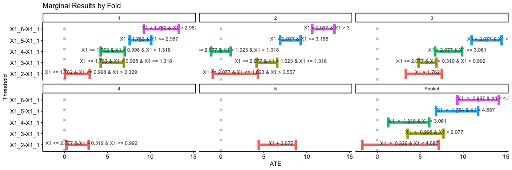

```r
marginal_plots <- plot_marginal_results(
  v_marginal_results = niehs_results$`V-Specific Marg Results`,
  mix_comps = c("X1", "X2", "X3", "X4", "X5", "X6", "X7"),
  hjust = 0.35)

marginal_plots$X1
```

So above we see the ATE estimates for each region level determined in each fold. You will notice the number of estimates in each fold lines up with the terminal nodes found in each decision tree for the variable X1.

## Estimate Stability

Because we are identifying thresholds in the marginal and mixture space data-adaptively using the training data as we rotate through the folds, `CVtreeMLE` will give, in the event that a signal actually exists, more consistent results when higher n_fold values are used. Thus, we recommend using 10-fold CV when possible for more consistent and interpretable results. Here, 5-fold was used simply for convenience in compiling and testing.

It should be noted that, especially in the marginal results, if the analyst chooses to report on results for one fold, which does have valid inference, the variability of the thresholds and estimates across the folds should also be provided for full transparency.

## References

Hubbard, Alan E., Sara Kherad-Pajouh, and Mark J. Van Der Laan. 2016. “Statistical Inference for Data Adaptive Target Parameters.” *International Journal of Biostatistics* 12 (1): 3–19. https://doi.org/10.1515/ijb-2015-0013.

van der Laan, Mark J, Jeremy R Coyle, Nima S Hejazi, Ivana Malenica, Rachael V Phillips, and Alan E Hubbard. 2022. *Targeted Learning in `R`: A Causal Data Science Handbook*. CRC Press. https://tlverse.org/tlverse-handbook/.

van der Laan, Mark J, and Sherri Rose. 2011. *Targeted Learning: Causal Inference for Observational and Experimental Data*. Springer Science & Business Media.

———. 2018. *Targeted Learning in Data Science: Causal Inference for Complex Longitudinal Studies*. Springer Science & Business Media.